# Trabalho Filmes R

Rafael Oliveira

2025-10-04

## Como reproduzir

- **Versão do R:** 4.4.2
- **Pacotes utilizados:** readr, dplyr, ggplot2, tidyverse, janitor, stringr, scales
- **Passos para gerar o relatório:**
  1. Abrir o ficheiro `Trabalho R.Rmd` no RStudio.
  2. Garantir que os ficheiros de dados (`dados_box_office.csv`, `title.basics.tsv`, `title.ratings.tsv`) estão na mesma pasta-dados trabalho r, dentro da pasta Data, dentro da pasta ADA
  3. Correr o código ou clicar em **Knit** → **HTML**.
  4. O relatório final será gerado automaticamente com os gráficos e interpretações.

## Carregar pacotes

```r
library(readr)
library(dplyr)
library(ggplot2)
library(tidyverse)
library(janitor)
library(stringr)
library(scales)
```

## Leitura de base de dados

```r
setwd("~/Desktop/ADA/Data/dados trabalho r")
box_office<- box_office <- read_delim(
  "dados_box_office.csv",
  delim = ";",
  locale = locale(encoding = "UTF-8"),
  quote = '"',
  trim_ws = TRUE,
  show_col_types = FALSE
)
imdb_ratings<- read_tsv("title.ratings.tsv")
imdb_basics<- read_tsv("title.basics.tsv")
```

## Limpar base de dados

```r
#limpar IMDB basics + ratings
dados_imdb<- imdb_basics %>%
  filter(titleType== "movie",startYear== 2025) %>%
  select(tconst, primaryTitle, startYear, genres,runtimeMinutes) %>%
  inner_join(clean_names(imdb_ratings), by = "tconst") %>%
  mutate(runtimeMinutes= suppressWarnings(as.numeric(runtimeMinutes)), title_clean= primaryTitle %>%
           str_to_lower() %>%
           str_squish() %>%
           str_replace_all("[^a-z0-9 ]", ""))

#limpar box_office
box_office<- box_office %>%
  clean_names() %>%
  mutate(release_group_clean = release_group %>%
           str_to_lower() %>%
           str_squish() %>%
           str_replace_all("[^a-z0-9 ]", ""),
         worldwide = readr::parse_number(worldwide),
         domestic  = readr::parse_number(domestic),
         foreign   = readr::parse_number(foreign))
```

## Juntar base de dados

```r
dados_finais<- dados_imdb %>%
  inner_join(box_office, by= c("title_clean" = "release_group_clean"))
dados_finais<- dados_finais %>%
  select(primaryTitle,startYear,genres,runtimeMinutes,average_rating,num_votes,rank,worldwide,domestic,foreign)
```

## Glossário de Variáveis

| Variável | Descrição |
| --- | --- |
| `primary_title` | Título principal do filme (IMDb). |
| `average_rating` | Rating médio dos utilizadores no IMDb (0–10). |
| `num_votes` | Número total de votos associados ao rating. |
| `genres` | Géneros atribuídos ao filme no IMDb. |
| `runtime_minutes` | Duração do filme em minutos. |
| `worldwide` | Receita mundial total (USD). |
| `domestic` | Receita obtida no mercado doméstico (USD). |
| `foreign` | Receita obtida fora do mercado doméstico (USD). |
| `foreign_share` | Percentagem da receita proveniente do mercado internacional. |

## Gráfico 1 — Distribuição dos géneros

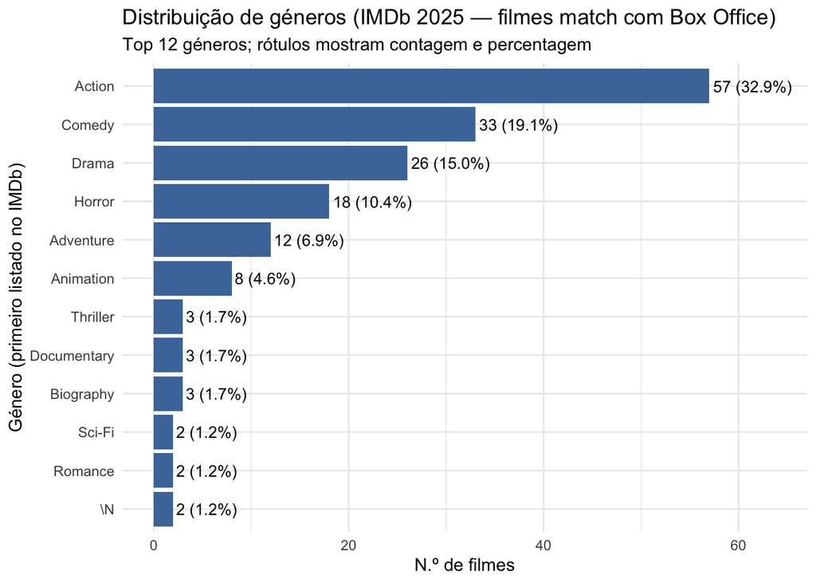

```r
# 1) Extrair 1.º género listado no IMDb e contar
dist_generos <- dados_finais %>%
  #Esta linha divide o texto em partes e guarda apenas o primeiro género   (coluna 'genero1').
   mutate(genero1 = str_split(genres, ",", simplify = TRUE)[,1]) %>%
  #Remove filmes sem informação de género (valores NA ou vazios).
  filter(!is.na(genero1), genero1 != "") %>%
  #Conta quantos filmes existem em cada género.
  count(genero1, name = "n") %>%
  #Ordena os géneros pela sua frequência (do mais comum para o menos comum).
  arrange(desc(n)) %>%
  #(%) que cada género representa em relação ao total de filmes.
  mutate(pct = n / sum(n))

# 2) Limitar aos top N géneros para o gráfico
topN <- 12
dist_generos_plot <- dist_generos %>%
  slice_head(n = topN) %>%
  mutate(rotulo = paste0(n, " (", percent(pct, accuracy = 0.1), ")"))

# 3) Gráfico: barras horizontais com rótulos
#x → os géneros (ordenados pela contagem 'n' em ordem crescente, para ficarem ordenados no gráfico), y → o número de filmes (n).
g_generos <- ggplot(dist_generos_plot,
                    aes(x = reorder(genero1, n), y = n)) +
  #Desenha as barras (gráfico de colunas) com uma cor azul uniforme (#4C78A8).
  geom_col(fill = "#4C78A8") +
  #Adiciona rótulos de texto ao lado de cada barra.
  geom_text(aes(label = rotulo), hjust = -0.05, size = 3.5) +
  #Inverte os eixos X e Y para deixar as barras horizontais.
  coord_flip() +
  #Expande o limite superior do eixo Y para criar espaço acima das barras.
  expand_limits(y = max(dist_generos_plot$n) * 1.12) +
  #Define o título, subtítulo e rótulos dos eixos
  labs(
    title = "Distribuição de géneros (IMDb 2025 — filmes match com Box Office)",
    subtitle = paste0("Top ", topN, " géneros; rótulos mostram contagem e percentagem"),
    x = "Género (primeiro listado no IMDb)",
    y = "N.º de filmes"
  ) +
  theme_minimal()

g_generos
```